# Mis respuestas

v1: 1 2 3

v2: 1 2 3 1 2 3 1 2 3

v3: 0 10 20 30 40 50 60 70 80 90 100

v5: 1 1 1 1 1

```r
v1 <- c(1,2,3) #Se llama c() para indicar que se separa por comas el vecto
v2 <- rep(v1, times=3)
v2
```

```
## [1] 1 2 3 1 2 3 1 2 3
```

```r
v3 <- seq(0,100, by = 10)
v3
```

```
##  [1]   0  10  20  30  40  50  60  70  80  90 100
```

```r
v4 <- seq(1000, 100, by = -100 )
v4
```

```
##  [1] 1000  900  800  700  600  500  400  300  200  100
```

```r
v5 <- rep(1,times=5)
```

# Excercise 2: Calculos a nivel de vector

1. Cacular la suma, media, rango, m?ximo y m?nimo de un vector de n?meros que contiene valores desde 1,500 hasta 500 step -2.
2. Ordenar el vector en orden creciente
3. Contar cuantos elementos hay en el vector.

```r
# Creamos un vector con esas características
v <- seq(1500, 500, by=-2)
suma <- sum(v)
suma
```

```
## [1] 501000
```

```r
media <- mean(v)
media
```

```
## [1] 1000
```

```r
max <- max(v)
max
```

```
## [1] 1500
```

```r
min <- min(v)
min
```

```
## [1] 500
```

Contar cuantos elementos hay en el vector.

#### 2) Ordenar el vector en orden creciente

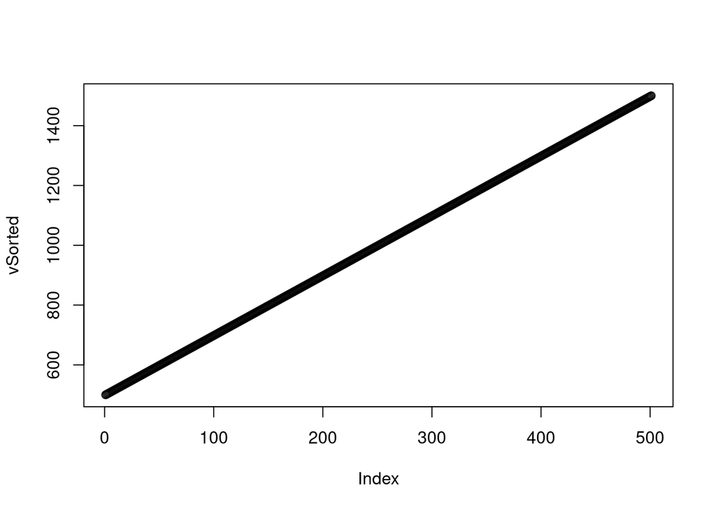

```r
# Creamos un vector con esas características
v <- seq(1500, 500, by=-2)
vSorted <- sort(v)
plot(vSorted)
```

#### 3) Contar cuantos elementos hay en el vector.

```r
# Creamos un vector con esas características
v <- seq(1500, 500, by=-2)
muestra <- length(v)
muestra
```

```
## [1] 501
```

# Excercise 3: Cálculos ariméticos con vectores numéricos

#### Crear un vector con valores de 1 a 20.

```r
v <-c(1:20)
v
```

```
##  [1]  1  2  3  4  5  6  7  8  9 10 11 12 13 14 15 16 17 18 19 20
```

#### Restar 1 a todos los elementos del vector

```r
v <- c(1 :20)
v - 1 # EL operador se aplicará a todos los elementos contenidos en el vector
```

```
##  [1]  0  1  2  3  4  5  6  7  8  9 10 11 12 13 14 15 16 17 18 19
```

#### Para cada elemento, calcular su cuadrado

```r
v <- c(1 :20)
v ^ 2
```

```
##  [1]   1   4   9  16  25  36  49  64  81 100 121 144 169 196 225 256 289 324 361
## [20] 400
```

# Vectores numéricos

Disponemos de un vector “quantity” y un vector de precios “price”:

- quantity: 20 3 4 5 6 7 8 5 2 12
- price: 2 4 5 63 40 21 12 6 7 4

Cada posición del vector quantity es la cantidad de productos vendidos. El precio está guardado en la misma posición del vector price. Calcular el precio total de todos los productos.

```r
quantity <- c(20,3,4,5,6,7,8,5,2,12)
price <- c(2,4,5,63,40,21,12,6,7,4)

# Calcular el precio total se puede hacer multiplicando ambos, ya que
# tienen el mismo tamaño, por lo que se mútiplican las posiciones
total_price_vector <- quantity * price
sum(total_price_vector)
```

```
## [1] 962
```

# Vectores numéricos y lógicos

Dados los siguientes vectores:

x: 3 4 6 -5 1 3 9 10 -1 0 -4

Realizar los cálculos siguientes:

1. Cuántos elementos del vector x son positivos?

   ```r
   x <- c(3,4,6,-5,1,3,9,10,-1,0, -4)
   y <- c(-4,4,6,5,13,9,1,-10,5)

   posx <- x>0
   posy <- y>0

   posx
   ```

   ```
   ##  [1]  TRUE  TRUE  TRUE FALSE  TRUE  TRUE  TRUE  TRUE FALSE FALSE FALSE
   ```

   ```r
   posy
   ```

   ```
   ## [1] FALSE  TRUE  TRUE  TRUE  TRUE  TRUE  TRUE FALSE  TRUE
   ```

2. Qué elementos del vector x son mayores que los elementos del vector y (considerando posición por posición).

   ```r
   #elements where x > y: index, elements, how many
   which( x>y )
   ```

   ```
   ## [1]  1  7  8 10
   ```

   ```r
   x[ x>y ] # Decimos que compare dentro del intervalo de X, no de Y
   ```

   ```
   ## [1]  3  9 10  0
   ```

   ```r
   length( which(x>y) )
   ```

   ```
   ## [1] 4
   ```

3. Borrar del vector x los elementos que son iguales a los elementos que ocupan la misma posición en y.

   ```r
   # Guardamos en X los elementos de y que no estan en X
   resDiffXY <- x[ !(x==y)]
   resDiffXY
   ```

   ```
   ## [1]  3 -5  1  3  9 10 -1  0 -4
   ```

# Factors

El siguiente vector pertenece al nivel de estudios de 20 personas:

studies <- c(“n”, “p”, “s”, “p”, “s”, “t”, “o”, “s”, “o” , “p”, “p”,“s”, “s”,“t”,“p”,“t”,“o”,“n”,“p”,“o”)

1. Calcular cuántos tipos de educación hay.

   ```r
   studies <- c("n", "p", "s", "p", "s", "t", "o", "s", "o" , "p", "p","s", "s","t","p","t","o","n","p","o")
   factorized_studies <- factor(studies) # cambio a variable categórica
   levels(factorized_studies) # Etiquetas de cada tipo de valor
   ```

   ```
   ## [1] "n" "o" "p" "s" "t"
   ```

   ```r
   length((levels(factorized_studies))) # contamos cuantas etiquetas != hay
   ```

   ```
   ## [1] 5
   ```

2. Para hacerlo más comprensible, cambiar el valor de los niveles a los siguientes:

   n : none

   p : primary

   s : secondary

   t : tertiary

   o : other

   ```r
   changedLevelsOfStudies <- levels(factorized_studies)
   changedLevelsOfStudies <- c("none", "primary", "secondary", "tertiary", "other")
   changedLevelsOfStudies
   ```

   ```
   ## [1] "none"      "primary"   "secondary" "tertiary"  "other"
   ```

3. Mostrar cuantas personas hay para cada tipo de educaci?n.

   ```r
   table(factorized_studies)
   ```

   ```
   ## factorized_studies
   ## n o p s t
   ## 2 4 6 5 3
   ```

# Matrices

1. Generar una matriz de 10 filas y 6 columnas, cuyos valores de cada columna son los m?ltiples del ?ndice de la columna, tal como sigue:

   [1,] 1 2 3 4 5 6

   [2,] 2 4 6 8 10 12

   [3,] 3 6 9 12 15 18

   [4,] 4 8 12 16 20 24

   [5,] 5 10 15 20 25 30

   [6,] 6 12 18 24 30 36

   [7,] 7 14 21 28 35 42

   [8,] 8 16 24 32 40 48

   [9,] 9 18 27 36 45 54

   [10,] 10 20 30 40 50 60

   ```r
   # Definicion de la matriz

   matrix <- matrix (c(1:60), nrow =10, ncol=6 )
   matrix
   ```

   ```
   ##       [,1] [,2] [,3] [,4] [,5] [,6]
   ##  [1,]    1   11   21   31   41   51
   ##  [2,]    2   12   22   32   42   52
   ##  [3,]    3   13   23   33   43   53
   ##  [4,]    4   14   24   34   44   54
   ##  [5,]    5   15   25   35   45   55
   ##  [6,]    6   16   26   36   46   56
   ##  [7,]    7   17   27   37   47   57
   ##  [8,]    8   18   28   38   48   58
   ##  [9,]    9   19   29   39   49   59
   ## [10,]   10   20   30   40   50   60
   ```

2. Etiquetar cada columna como: M1, M2, … M6

   ```r
   # Creamos las nuevas columnas
   nom_columns <- paste0("M", 1:ncol(matrix)) # Concatena string
   colnames(matrix) <- nom_columns
   matrix
   ```

   ```
   ##       M1 M2 M3 M4 M5 M6
   ##  [1,]  1 11 21 31 41 51
   ##  [2,]  2 12 22 32 42 52
   ##  [3,]  3 13 23 33 43 53
   ##  [4,]  4 14 24 34 44 54
   ##  [5,]  5 15 25 35 45 55
   ##  [6,]  6 16 26 36 46 56
   ##  [7,]  7 17 27 37 47 57
   ##  [8,]  8 18 28 38 48 58
   ##  [9,]  9 19 29 39 49 59
   ## [10,] 10 20 30 40 50 60
   ```

3. Borrar las dos últimas filas.

   ```r
   matrix_without_last <- matrix[-10,] # Puedes quitar 1
   matrix <- matrix[c(-9,-10),] # Eliminamos varias filas a la vez
   matrix
   ```

   ```
   ##      M1 M2 M3 M4 M5 M6
   ## [1,]  1 11 21 31 41 51
   ## [2,]  2 12 22 32 42 52
   ## [3,]  3 13 23 33 43 53
   ## [4,]  4 14 24 34 44 54
   ## [5,]  5 15 25 35 45 55
   ## [6,]  6 16 26 36 46 56
   ## [7,]  7 17 27 37 47 57
   ## [8,]  8 18 28 38 48 58
   ```

   ```r
   matrix[3,] <- matrix[3,]*-1 # OJO hay que poner , para sacar la fila
   matrix
   ```

   ```
   ##      M1  M2  M3  M4  M5  M6
   ## [1,]  1  11  21  31  41  51
   ## [2,]  2  12  22  32  42  52
   ## [3,] -3 -13 -23 -33 -43 -53
   ## [4,]  4  14  24  34  44  54
   ## [5,]  5  15  25  35  45  55
   ## [6,]  6  16  26  36  46  56
   ## [7,]  7  17  27  37  47  57
   ## [8,]  8  18  28  38  48  58
   ```

5. Mostrar el contenido de la columna 2

   ```r
   matrix[,2] # POR Número
   ```

   ```
   ## [1]  11  12 -13  14  15  16  17  18
   ```

   ```r
   matrix[, "M2"] # Al tener etiqueta podemos usar nombre de etiqueta
   ```

   ```
   ## [1]  11  12 -13  14  15  16  17  18
   ```

# Data Frames (“ejercicio avanzado”)

1. Leer el fichero “bank.csv” (http://archive.ics.uci.edu/ml/datasets/Bank+Marketing) y guardar los datos en un data frame. Verificar que la informaci?n se ha le?do correctamente en el data.frame.

   ```r
   csv_location <- "../BankCSV/bank.csv"
   data_bank <- read.csv(csv_location,sep=";",na.strings = "NA")
   head(data_bank)
   ```

   |  | age | job | marital | education | default | balance | housing | loan | contact | day | month | duration | campaign | pdays | previous | poutcome | y |
   | --- | --- | --- | --- | --- | --- | --- | --- | --- | --- | --- | --- | --- | --- | --- | --- | --- | --- |
   | 1 | 30 | unemployed | married | primary | no | 1787 | no | no | cellular | 19 | oct | 79 | 1 | -1 | 0 | unknown | no |
   | 2 | 33 | services | married | secondary | no | 4789 | yes | yes | cellular | 11 | may | 220 | 1 | 339 | 4 | failure | no |
   | 3 | 35 | management | single | tertiary | no | 1350 | yes | no | cellular | 16 | apr | 185 | 1 | 330 | 1 | failure | no |
   | 4 | 30 | management | married | tertiary | no | 1476 | yes | yes | unknown | 3 | jun | 199 | 4 | -1 | 0 | unknown | no |
   | 5 | 59 | blue-collar | married | secondary | no | 0 | yes | no | unknown | 5 | may | 226 | 1 | -1 | 0 | unknown | no |
   | 6 | 35 | management | single | tertiary | no | 747 | no | no | cellular | 23 | feb | 141 | 2 | 176 | 3 | failure | no |

2. Calcular el promedio de edad.

   ```r
   mean(data_bank$age)
   ```

   ```
   ## [1] 41.1701
   ```

3. Calcular cuantos trabajos diferentes hay en la muestra.

   ```r
   unique(data_bank$job)
   ```

   ```
   ##  [1] "unemployed"    "services"      "management"    "blue-collar"
   ##  [5] "self-employed" "technician"    "entrepreneur"  "admin."
   ##  [9] "student"       "housemaid"     "retired"       "unknown"
   ```

   ```r
   # Obtenemos el numero
   length(unique(data_bank$job))
   ```

   ```
   ## [1] 12
   ```

4. Calcular cuantas personas hay de cada tipo de trabajo.

   ```r
   table(data_bank$job)# Hacemos una tabla para c
   ```

   ```
   ##
   ##        admin.   blue-collar  entrepreneur     housemaid    management
   ##           478           946           168           112           969
   ##       retired self-employed      services       student    technician
   ##           230           183           417            84           768
   ##    unemployed       unknown
   ##           128            38
   ```

5. Calcular cuantos “entprepreneurs” hay.

   ```r
   table( data_bank$job )['entrepreneur']# Hacemos una tabla para c
   ```

   ```
   ## entrepreneur
   ##          168
   ```

6. Seleccionar los individuos que son emprendedores y calcular su promedio de edad.

   ```r
   entreReg <- data_bank[ data_bank$job == 'entrepreneur',]# Pillamos solo las filas de entrepreneur
   nrow(entreReg)
   ```

   ```
   ## [1] 168
   ```

   ```r
   mean(entreReg$age)
   ```

   ```
   ## [1] 42.0119
   ```

7. Seleccionar los emprenedores cuya edad es inferior al promedio de edad de los emprenedeores. ?Cu?ntos son?

   ```r
   avgEntre <- mean(entreReg$age)
   youngEntreReg <- entreReg[entreReg$age < avgEntre, ]
   nrow(youngEntreReg)
   ```

   ```
   ## [1] 94
   ```

8. ?Cu?l es el nivel de estudios de estos emprendedores j?venes?

   ```r
   unique(youngEntreReg$education)
   ```

   ```
   ## [1] "tertiary"  "primary"   "unknown"   "secondary"
   ```

9. Borrar del data frame todos los emprendedores j?venes.

   ```r
   # Pillamos los entrepreneurs jovenes, con which pillamos los indices
   entrepReg <- which(data_bank$job == 'entrepreneur' & data_bank$age < avgEntre)
   nrow(data_bank)
   ```

   ```
   ## [1] 4521
   ```

   ```r
   data_bank <- data_bank[-entrepReg,]
   #despues
   nrow(data_bank)
   ```

   ```
   ## [1] 4427
   ```